# CANTO - preprocessing

January 2, 2020

The original dataset in BI contains 9752 samples and 1013 columns.

# Clinical variables

## Bilateral

```r
data.workBI$bilat <- factor(NA, levels = c("no","yes"))
data.workBI$bilat[which(data.workBI$LOC %in% c("1","2"))] <- "no"
data.workBI$bilat[which(data.workBI$LOC %in% c("3"))] <- "yes"
data.workBI$bilat <- addNA(data.workBI$bilat)
table(data.workBI$bilat)
```

```
##
##   no  yes <NA>
## 9510  227   15
```

We remove 227 bilateral cases and 15 NAs

```r
###REMOVE BILATERAL
nobilat = which(data.workBI$bilat=="no")
data.workBI = data.workBI %>% filter(bilat=="no")
data.workBI$side <- unlist(lapply(data.workBI$LOC, function(x){if(x==1) "L" else "R"}))
table(data.workBI$side)
```

```
##
##    L    R
## 4857 4653
```

We obtain 9510 samples.

## Bifocal

```r
data.workBI$bifocal <- factor(NA, levels = c("no","yes"))
data.workBI$bifocal[which(data.workBI$LOC %in% c("1") & data.workBI$FORME_G %in% c("1"))] <- "no"
data.workBI$bifocal[which(data.workBI$LOC %in% c("1") & data.workBI$FORME_G %in% c("2"))] <- "yes"
data.workBI$bifocal[which(data.workBI$LOC %in% c("2") & data.workBI$FORME_D %in% c("1"))] <- "no"
data.workBI$bifocal[which(data.workBI$LOC %in% c("2") & data.workBI$FORME_D %in% c("2"))] <- "yes"
table(data.workBI$bifocal)
```

```
##
##   no  yes
## 7514  886
```

We keep bifocal patients.

## Date of diagnosis

```r
vec = c(grep("ND",data.workBI$DTDIAG), grep("NK",data.workBI$DTDIAG), grep("NA/",data.workBI$DTDIAG))
look = which(!vec %in%  c(grep("NKNKNK",data.workBI$DTDIAG), grep("ND/ND",data.workBI$DTDIAG), grep("NK/NK",data.workBI$DTDIAG),grep("NA/NA",data.workBI$DTDIAG)))
vec = vec[look]
length(vec)
```

```
## [1] 413
```

We have 413 patients with dates as NK/mm/yyyy. We set for them the diagnosis at 1st of the month. We still have dates like:

```r
ind = which(data.workBI$DTDIAG=="02092013")
if(length(ind)>0)
  data.workBI$DTDIAG[which(data.workBI$DTDIAG=="02092013")] = "02/09/2013"

data.workBI$DTDIAG[vec] =  paste("01/",substr(data.workBI$DTDIAG[vec],4,10),sep="")
data.workBI <- mutate(data.workBI, DT_Diagnosis = as.Date(DTDIAG, "%d/%m/%Y"))
t=which(is.na(as.Date(data.workBI$DTDIAG)))
data.workBI$DTDIAG[t]
```

```
##  [1] "NK/NK/2012" "NK/NK/2012" "NK/NK/2012" "NK/NK/2012" "NK/NK/2012"
##  [6] "K"          "NK/NK/2012" "NK/NK/2012" "NK/NK/2012" "NK/NK/2012"
## [11] "NK/NK/2012" "NK/NK/2013" "NK/NK/2013" "NK/NK/2013" "K"
## [16] "NK/NK/2013" "NK/NK/2016" "NK/NK/2013" "NK/NK/2013" "K"
## [21] "NK/NK/2013" "NK/NK/2013" "NK/NK/2014" "NK/NK/2014" "NK/NK/2014"
## [26] "NK/NK/2014" "NK/NK/2014" "K"          "NK/NK/2015" "K"
## [31] "NK/NK/2015" "NK/NK/2015" "NK/NK/2015" "K"          "NK/NK/2015"
## [36] "K"          "NK/NK/2015" "K"          "K"          "K"
## [41] "NK/NK/2015" "NK/NK/2015" "K"          "K"          "NK/NK/2015"
## [46] "NK/NK/2015" "K"          "NK/NK/2015" "NK/NK/2015" "NK/NK/2013"
## [51] ""           "NK/NK/2012" "NK/NK/2012" "K"          "K"
## [56] "K"          "NA/NA/2012" "NA/NA/2012" "NK/NK/2013" "NK/NK/2013"
## [61] "NK/NK/2015" "K"          "K"          "K"          "NK/NK/2013"
## [66] "NK/NK/2013" "NK/NK/2015" "K"          "K"          "K"
## [71] "K"          "K"          "NK/NK/2013" "NK/NK/2016" "NK/NK/2016"
## [76] "K"          "D"          "ND/ND/2013" "NK/NK/2014"
```

For these patients here the date of biopsy and inscription in the base

```r
dd = data.frame(date_diagnosis = data.workBI$DTDIAG[t], date_biopsy = data.workBI$DTEXAM_BI[t], date_insertion_base = data.workBI$DTCREATION[t])
dd
```

| date_diagnosis | date_biopsy | date_insertion_base |
| --- | --- | --- |
| NK/NK/2012 | 10/08/2012 | 13/08/2012 |
| NK/NK/2012 | 31/08/2012 | 03/09/2012 |
| NK/NK/2012 | 15/10/2012 | 15/10/2012 |
| NK/NK/2012 | 07/11/2012 | 08/11/2012 |
| NK/NK/2012 | 22/11/2012 | 23/11/2012 |
| K | 10/12/2012 | 17/12/2012 |
| NK/NK/2012 | 12/12/2012 | 17/12/2012 |
| NK/NK/2012 | 03/01/2013 | 04/01/2013 |
| NK/NK/2012 | 03/01/2013 | 04/01/2013 |
| NK/NK/2012 | 14/01/2013 | 14/01/2013 |

[output cut: 69 more lines]

Take the date of biopsy for dates not known

```r
data.workBI$DTDIAG[t] = data.workBI$DTEXAM_BI[t]
t=which(is.na(as.Date(data.workBI$DTDIAG)))
```

We still have 2 NAs. In this case take the date of insertion in the base

```r
data.workBI$DTDIAG[t] = data.workBI$DTCREATION[t]

data.workBI <- mutate(data.workBI, DATDIAG = as.Date(DTDIAG, "%d/%m/%Y"))
length(which(is.na(as.Date(data.workBI$DTDIAG))))
```

```
## [1] 0
```

## Number of family history of breast cancer

```r
data.workBI$NB_Hist_Breast_Cancer1 <- as.numeric(data.workBI$NBANTECSEIN1)

#========== Create composite variable of family history just for first degree family
data.workBI$fam_hist_bc <- factor(NA, levels = c("no","yes"))
data.workBI$fam_hist_bc[which(data.workBI$NB_Hist_Breast_Cancer1==0)] <- "no"
data.workBI$fam_hist_bc[which(data.workBI$NB_Hist_Breast_Cancer1>0)] <- "yes"
table(data.workBI$fam_hist_bc)
```

```
##
##   no  yes
## 7236 2099
```

# Clinical tumor characteristics

## Clinical size

```r
data.workBI$tailleclin <- NA
data.workBI$tailleclin[which(data.workBI$side %in% c("L"))] <- data.workBI$tclin_L[which(data.workBI$side %in% c("L"))]
data.workBI$tailleclin[which(data.workBI$side %in% c("R"))] <- data.workBI$tclin_R[which(data.workBI$side %in% c("R"))]
table(data.workBI$tailleclin, exclude = NULL)
```

```
##
##    0    1    2    3    4    5    6  6.1    7  7.5    8  8.8    9   10   11   12
## 2160   22   11   16   25   56   56    1   88    1   99    1   68  692   60  121
##   13   14   15   16   17   18   19   20   21   22   23   24   25   26   27   28
##   45   35  619   39   30   49   17  965   17   39   18   10  361    8    5   15
##   29   30   31   32   33   34   35   36   37   38   39   40   42   43   44   45
##    5  644    1    3    2    5  161    2    3    2    1  423    2    1    1   71
##   46   50   51   55   58   60   65   70   75   77   80   85   90  100  120  140
##    1  292    3   23    1  161   12   93    3    1   46    3   20   29    3    1
## <NA>
## 1742
```

## Tumor form

```r
data.workBI$form <- factor(NA, levels = c("unifocal", "multifocal"))
data.workBI$form[which(data.workBI$side %in% c("L"))] <- data.workBI$form_L[which(data.workBI$side %in% c("L"))]
data.workBI$form[which(data.workBI$side %in% c("R"))] <- data.workBI$form_R[which(data.workBI$side %in% c("R"))]
table(data.workBI$form, exclude = NULL)
```

```
##
##   unifocal multifocal       <NA>
##       7514        886       1110
```

## ctuicc_5cl

```r
data.workBI$ctuicc_5cl <- factor(NA,levels = c("T0", "T1", "T2", "T3","T4"))
data.workBI$ctuicc_5cl[which(data.workBI$side %in%c("L"))] <- data.workBI$tuicc_5cl_L[which(data.workBI$side %in%c("L"))]
data.workBI$ctuicc_5cl[which(data.workBI$side %in%c("R"))] <- data.workBI$tuicc_5cl_R[which(data.workBI$side %in%c("R"))]
table(data.workBI$ctuicc_5cl, exclude = NULL)
```

```
##
##   T0   T1   T2   T3   T4 <NA>
## 2160 3150 2093  399    0 1708
```

## Clinical nodal status (4 classes)

```r
data.workBI$cnuicc_4cl <- factor(NA, levels = c("N0","N1","N2","N3"))
data.workBI$cnuicc_4cl[which(data.workBI$side %in%c("L"))] <- data.workBI$nuicc_4cl_L[which(data.workBI$side %in%c("L"))]
data.workBI$cnuicc_4cl[which(data.workBI$side %in%c("R"))] <- data.workBI$nuicc_4cl_R[which(data.workBI$side %in%c("R"))]
table(data.workBI$cnuicc_4cl, exclude = NULL)
```

```
##
##   N0   N1   N2   N3 <NA>
## 7686  862   53    9  900
```

# Tumor characteristics - biopsy

```r
##### Function for marking individuals with unilateral cancer, but with informations for both left and right breast
incompability2 <- function(data, var_left, var_right){

  warning <- rep(0,nrow(data))
  for (i in 1:nrow(data)) {
    for (c in 1:length(var_left)) {
      if(warning[i]==0){
        warning[i] <- ifelse(!is.na(data[i,which(colnames(data)==var_left[c])]) & !is.na(data[i,which(colnames(data)==var_right[c])]),1,0)
        #if(warning[i]==1)print(paste(i,c,var_left[c],var_right[c]))
      }
    }
  }

  return(warning)
}

var_right_biop=c("mat_type_R","invasive_biop_R","histo_4cl_biop_R","histo_3cl_biop_R",
            "index_mitotic_biop_R","dcis_biop_R","grade_3cl_biop_R","grade_2cl_biop_R",
            "biopsy_R","er_biop_R","perc_er_biop_R","inte_er_biop_R",
            "pr_biop_R","perc_pr_biop_R","inte_pr_biop_R",
            "her2_biop_R","her2_ihc_biop_R","Ki67_biop_bi_R","Ki67_biop_R","genom_biop_bi_R")

var_left_biop=c("mat_type_L","invasive_biop_L","histo_4cl_biop_L","histo_3cl_biop_L",
           "index_mitotic_biop_L","dcis_biop_L","grade_3cl_biop_L","grade_2cl_biop_L",
           "biopsy_L","er_biop_L","perc_er_biop_L","inte_er_biop_L",
           "pr_biop_L","perc_pr_biop_L","inte_pr_biop_L",
           "her2_biop_L","her2_ihc_biop_L","Ki67_biop_bi_L","Ki67_biop_L","genom_biop_bi_L")

incomp <- incompability2(data.workBI,
                        var_right=var_right_biop,
                        var_left=var_left_biop)

data.workBI$warning_biop <- incomp
table(data.workBI$warning_biop, exclude = NULL)
```

```
##
##    0    1
## 9467   43
```

We have 43 patients with unilateral cancer but with data for both left and right breast (we have 20 columns for biopsy for each breast). Here the table for biopsy related variables for these patients. Every patient has 2 rows: one for left and one for right breast side.

| ID | OFFICIAL SIDE | INSPECTED SIDE | # NOT NA | mat_type | invasive_biop | histo_4cl_biop | histo_3cl_biop | index_mitotic_biop | dcis_biop | grade_3cl_biop | grade_2cl_biop | biopsy | er_biop | perc_er_biop | inte_er_biop | pr_biop | perc_pr_biop | inte_pr_biop | her2_biop | her2_ihc_biop | Ki67_biop_bi | Ki67_biop | genom_biop_bi |
| --- | --- | --- | --- | --- | --- | --- | --- | --- | --- | --- | --- | --- | --- | --- | --- | --- | --- | --- | --- | --- | --- | --- | --- |
| 19 | R | L | 1 | NA | 2 | NA | NA | NA | NA | NA | NA | NA | NA | NA | NA | NA | NA | NA | NA | NA | NA | NA | NA |
| 19 | R | R | 16 | 1 | 2 | 1 | 1 | NA | 2 | 2 | 1 | 2 | 1 | 30 | 1 | 1 | 30 | 1 | 1 | 4 | NA | NA | NA |
| 21 | L | L | 5 | 3 | 2 | NA | NA | NA | NA | NA | NA | 1 | 1 | NA | NA | 1 | NA | NA | NA | NA | NA | NA | NA |
| 21 | L | R | 1 | NA | 1 | NA | NA | NA | NA | NA | NA | NA | NA | NA | NA | NA | NA | NA | NA | NA | NA | NA | NA |
| 24 | L | L | 5 | 3 | 2 | NA | NA | NA | NA | NA | NA | 1 | 1 | NA | NA | 1 | NA | NA | NA | NA | NA | NA | NA |
| 24 | L | R | 1 | NA | 1 | NA | NA | NA | NA | NA | NA | NA | NA | NA | NA | NA | NA | NA | NA | NA | NA | NA | NA |
| 28 | R | L | 1 | NA | 1 | NA | NA | NA | NA | NA | NA | NA | NA | NA | NA | NA | NA | NA | NA | NA | NA | NA | NA |
| 28 | R | R | 5 | 3 | 2 | NA | NA | NA | NA | NA | NA | 1 | 1 | NA | NA | 1 | NA | NA | NA | NA | NA | NA | NA |
| 31 | R | L | 1 | NA | 1 | NA | NA | NA | NA | NA | NA | NA | NA | NA | NA | NA | NA | NA | NA | NA | NA | NA | NA |
| 31 | R | R | 5 | 3 | 2 | NA | NA | NA | NA | NA | NA | 1 | 1 | NA | NA | 1 | NA | NA | NA | NA | NA | NA | NA |

[output cut: 76 more lines]

We need to pay attention to some patients, some of theme seem to be bilateral?

## Define biopsy side based on left or right breast biopsy:

Is it consistent with breast side?

```r
#### Define all variables based on left or right breast tumor
left_right <- function(data, var_left, var_right){

  side <- rep(NA,nrow(data))
  for (i in 1:nrow(data)) {
    for (l in var_left) {
      if(data[i,"bilat"]=="no" & data[i,"warning_biop"]==0){
          side[i] <- ifelse(!is.na(data[i,l]), "L", side[i])
      }
      if(data[i,"bilat"]=="no" & data[i,"warning_biop"]==1){
        side[i] <- NA
      }
      if(data[i,"bilat"]=="yes"){
        side[i] <- NA
      }
    }
    for (r in var_right) {
      if(data[i,"bilat"]=="no" & data[i,"warning_biop"]==0){
        side[i] <- ifelse(!is.na(data[i,r]), "R", side[i])
      }
      if(data[i,"bilat"]=="no" & data[i,"warning_biop"]==1){
        side[i] <- NA
      }
      if(data[i,"bilat"]=="yes"){
        side[i] <- NA
      }
    }
  }

  return(side)

}

side <- left_right(data.workBI,
                   var_right=var_right_biop,
                   var_left=var_left_biop)

data.workBI$breast_biop <- as.factor(side)

table(data.workBI$breast_biop,data.workBI$warning_biop, exclude = NULL, dnn = c("SIDE (biopsy)", "Info both L/R"))
```

```
##              Info both L/R
## SIDE (biopsy)    0    1
##          L    4835    0
##          R    4630    0
##          <NA>    2   43
```

We also have 2 individuals with no information on right or left side.

We keep the side for biopsy as the one saved in variable LOC.

## Biopsy performed

```r
data.workBI$biopsy <- factor(ifelse(data.workBI$breast_biop %in% c("L"), as.character(data.workBI$biopsy_L), as.character(data.workBI$biopsy_R)))
table(data.workBI$biopsy, exclude = NULL)
```

```
##
##   no  yes <NA>
##  560 8848  102
```

```r
data.workBI$breast_biop <- data.workBI$side
```

## Histological type (3 classes)

```r
#================ Invasive cancer =================
data.workBI$invasive_biop <- factor(ifelse(data.workBI$breast_biop %in% c("L"), as.character(data.workBI$invasive_biop_L), as.character(data.workBI$invasive_biop_R)))

# histological type (4 classes)
data.workBI$histo_4cl_biop <- factor(ifelse(data.workBI$breast_biop %in% c("L"), as.character(data.workBI$histo_4cl_biop_L), as.character(data.workBI$histo_4cl_biop_R)))

# histological type (3 classes)
data.workBI$histo_3cl_biop <- data.workBI$histo_4cl_biop
levels(data.workBI$histo_3cl_biop) <- c("NST","lobular","others","others")
table(data.workBI$histo_3cl_biop, exclude = NULL)
```

```
##
##     NST lobular  others    <NA>
##    1153      73    7921     363
```

## Mitotic index biopsy

```r
data.workBI$index_mitotic_biop <- factor(ifelse(data.workBI$breast_biop %in% c("L"), as.numeric(data.workBI$index_mitotic_biop_L), as.numeric(data.workBI$index_mitotic_biop_R)))
table(data.workBI$index_mitotic_biop, exclude = NULL)
```

```
##
##    1    2    3 <NA>
## 5344 1654  823 1689
```

## Dcis component biopsy

```r
# In situ
data.workBI$dcis_biop <- factor(ifelse(data.workBI$breast_biop %in% c("L"), as.character(data.workBI$dcis_biop_L), as.character(data.workBI$dcis_biop_R)))
table(data.workBI$dcis_biop, exclude = NULL)
```

```
##
##   no  yes <NA>
## 5669 2205 1636
```

## Invasive or dcis biopsy

```r
# Invasive or in situ
data.workBI <- data.workBI %>% mutate(inv_or_insitu_biop = case_when(
                          invasive_biop == 'yes' & dcis_biop == 'no' ~ 'invasive',
                          invasive_biop == 'no' & dcis_biop == 'yes' ~ 'dcis'))
table(data.workBI$inv_or_insitu_biop, exclude = NULL)
```

```
##
##     dcis invasive     <NA>
##        5     5657     3848
```

## Grade 3cl biopsy

```r
# Grade (3 classes)
data.workBI$grade_3cl_biop <- factor(ifelse(data.workBI$breast_biop %in% c("L"), as.character(data.workBI$grade_3cl_biop_L), as.character(data.workBI$grade_3cl_biop_R)))
table(data.workBI$grade_3cl_biop, exclude = NULL)
```

```
##
##   Grade I  Grade II Grade III      <NA>
##      2456      4900      1586       568
```

## ER biopsy

```r
data.workBI$er_biop <- factor(ifelse(data.workBI$breast_biop %in% c("L"), as.character(data.workBI$er_biop_L), as.character(data.workBI$er_biop_R)))
table(data.workBI$er_biop, exclude = NULL)
```

```
##
## negative positive     <NA>
##     1387     8013      110
```

```r
# Percentage
data.workBI$perc_er_biop <- factor(ifelse(data.workBI$breast_biop %in% c("L"), as.numeric(data.workBI$perc_er_biop_L), as.numeric(data.workBI$perc_er_biop_R)))

# Intensity
data.workBI$inte_er_biop <- factor(ifelse(data.workBI$breast_biop %in% c("L"), as.numeric(data.workBI$inte_er_biop_L), as.numeric(data.workBI$inte_er_biop_R)))
```

## PR biopsy

```r
data.workBI$pr_biop <- factor(ifelse(data.workBI$breast_biop %in% c("L"), as.character(data.workBI$pr_biop_L), as.character(data.workBI$pr_biop_R)))
table(data.workBI$pr_biop, exclude = NULL)
```

```
##
## negative positive     <NA>
##     2721     6667      122
```

```r
# Percentage
data.workBI$perc_pr_biop <- factor(ifelse(data.workBI$breast_biop %in% c("L"), as.numeric(data.workBI$perc_pr_biop_L), as.numeric(data.workBI$perc_pr_biop_R)))

# Intensity
data.workBI$inte_pr_biop <- factor(ifelse(data.workBI$breast_biop %in% c("L"), as.numeric(data.workBI$inte_pr_biop_L), as.numeric(data.workBI$inte_pr_biop_R)))
```

## HER2 biopsy

```r
data.workBI$her2_biop <- factor(ifelse(data.workBI$breast_biop %in% c("L"), as.character(data.workBI$her2_biop_L), as.character(data.workBI$her2_biop_R)))
table(data.workBI$her2_biop, exclude = NULL)
```

```
##
## negative positive     <NA>
##     6565     1159     1786
```

```r
data.workBI$her2_ihc_biop <- factor(ifelse(data.workBI$breast_biop %in% c("L"), as.character(data.workBI$her2_ihc_biop_L), as.character(data.workBI$her2_ihc_biop_R)))
```

## Ki67 percentage biopsy

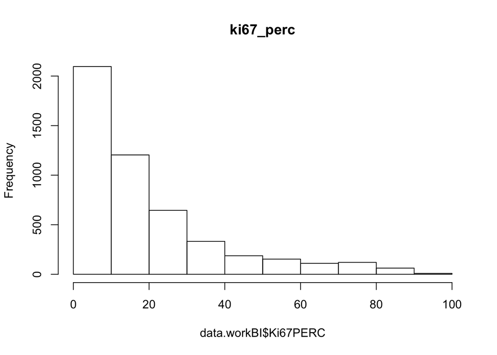

```r
data.workBI$fish_bi <- factor(ifelse(data.workBI$breast_biop %in% c("L"), as.character(data.workBI$fish_bi_L), as.character(data.workBI$fish_bi_R)))

data.workBI$Ki67_biop_bi <- factor(ifelse(data.workBI$breast_biop %in% c("L"), as.character(data.workBI$Ki67_biop_bi_L), as.character(data.workBI$Ki67_biop_bi_R)))

data.workBI$Ki67_biop <- factor(ifelse(data.workBI$breast_biop %in% c("L"), as.numeric(data.workBI$Ki67_biop_L), as.numeric(data.workBI$Ki67_biop_R)))

data.workBI$Ki67_cl_biop <- factor(ifelse(data.workBI$breast_biop %in% c("L"), as.numeric(data.workBI$Ki67_cl_biop_L), as.numeric(data.workBI$Ki67_cl_biop_R)))

data.workBI$Ki67PERC <- as.numeric(ifelse(data.workBI$breast_biop %in% c("L"), as.character(data.workBI$POURCKI67_G_BI), as.character(data.workBI$POURCKI67_D_BI)))
hist(data.workBI$Ki67PERC, main = 'ki67_perc')
```

## Genomic test biopsy

```r
# Genomic test
data.workBI$genom_biop_bi <- factor(ifelse(data.workBI$breast_biop %in% c("L"), as.character(data.workBI$genom_biop_bi_L), as.character(data.workBI$genom_biop_bi_R)))

table(data.workBI$genom_biop_bi, exclude = NULL)
```

```
##
##     done not done     <NA>
##       85     4892     4533
```

# Surgery

## Individuals with unilateral cancer, but with informations for both sides

```r
incompability2 <- function(data, var_left, var_right){

  warning <- rep(0,nrow(data))
  for (i in 1:nrow(data)) {
    for (c in 1:length(var_left)) {
      if(warning[i]==0){
        warning[i] <- ifelse(!is.na(data[i,which(colnames(data)==var_left[c])]) & !is.na(data[i,which(colnames(data)==var_right[c])]),1,0)
        #if(warning[i]==1){
          #print(paste(i,var_left[c], data[i,which(colnames(data)==var_left[c])], data[i,which(colnames(data)==var_right[c])]))
        #}
      }

    }
  }

  return(warning)
}

var_right_surg=c("pT_R","pN_R","nbggpos_R","taillehisto_R","multifocal_R","infiltrant_cancer_surg_R",
                                    "histo_4cl_surg_R","histo_3cl_surg_R","grade_3cl_surg_R","grade_2cl_surg_R",
                                    "index_mitotic_surg_R","dcis_surg_R","surgery_R","breast_surgery_R",
                                    "axillary_surgery_R","comp_post_surg_R","er_surg_R","perc_er_surg_R",
                                    "inte_er_surg_R","pr_surg_R","perc_pr_surg_R","inte_pr_surg_R","her2_surg_R",
                                    "her2_ihc_surg_R","Ki67_surg_bi_R","Ki67_surg_R","Ki67_cl_surg_R","genom_surg_bi_R")

var_left_surg=c("pT_L","pN_L","nbggpos_L","taillehisto_L","multifocal_L","infiltrant_cancer_surg_L",
           "histo_4cl_surg_L","histo_3cl_surg_L","grade_3cl_surg_L","grade_2cl_surg_L",
           "index_mitotic_surg_L","dcis_surg_L","surgery_L","breast_surgery_L",
           "axillary_surgery_L","comp_post_surg_L","er_surg_L","perc_er_surg_L",
           "inte_er_surg_L","pr_surg_L","perc_pr_surg_L","inte_pr_surg_L","her2_surg_L",
           "her2_ihc_surg_L","Ki67_surg_bi_L","Ki67_surg_L","Ki67_cl_surg_L","genom_surg_bi_L")

incomp <- incompability2(data.work,

                        var_right = var_right_surg,
                        var_left = var_left_surg)


data.work$warning_surg <- incomp
table(data.work$warning_surg, exclude = NULL)
```

```
##
##    0    1
## 9488   22
```

We have 22 patients with informations on both sides but with unilateral cancer.

## Define side based on left or right breast surgery:

Is it consistent with breast side?

```r
left_right <- function(data, var_left, var_right){

  side <- rep(NA,nrow(data))
  for (i in 1:nrow(data)) {
    for (l in var_left) {
      if(data[i,"warning_surg"]==0){
        side[i] <- ifelse(!is.na(data[i,l]), "L", side[i])
      }
      if(data[i,"warning_surg"]==1){
        side[i] <- NA
      }
    }
    for (r in var_right) {
      if(data[i,"warning_surg"]==0){
        side[i] <- ifelse(!is.na(data[i,r]), "R", side[i])
      }
      if(data[i,"warning_surg"]==1){
        side[i] <- NA
      }
    }
  }

  return(side)

}

side <- left_right(data.work,
                   var_right=var_right_surg,
                   var_left=var_left_surg)

data.work$breast_surg_side <- as.factor(side)

table(data.work$breast_surg_side,data.work$warning_surg, exclude = NULL, dnn = c("SIDE", "Info both L/R"))
```

```
##       Info both L/R
## SIDE      0    1
##   L    4802    0
##   R    4595    0
##   <NA>   91   22
```

We have 91 individuals with unilateral cancer with no information on left or right breast and 22 individuals with informations on both sides but with unilateral cancer.

We inspect values for left and right, as we have done for biopsy:

```r
columns = which(data.work$warning_surg == 1)
rr = as.data.frame(matrix(NA, nrow = 2*length(columns), ncol=length(var_left_surg)+4))
rr[,3] = rep(c("L","R"),length(columns))
colnames(rr) = c("ID", "OFFICIAL SIDE", "INSPECTED SIDE", "# NOT NA", unlist(lapply(var_left_surg, function(x){substr(x,0,nchar(x)-2)})))
i = 1
for(c in columns){
  rr[i,1] = c
  rr[i+1,1] = c
  rr[i,2] = if(data.work$LOC[c]==1) "L" else "R"
  rr[i+1,2] = if(data.work$LOC[c]==1) "L" else "R"
  rr[i,4] = length(which(!is.na(data.work[c,var_left_surg])))
  rr[i+1,4] = length(which(!is.na(data.work[c,var_right_surg])))
  rr[i,5:ncol(rr)] = data.work[c,var_left_surg]
  rr[i+1,5:ncol(rr)] = data.work[c,var_right_surg]
  i = i + 2
}
rr
```

| ID | OFFICIAL SIDE | INSPECTED SIDE | # NOT NA | pT | pN | nbggpos | taillehisto | multifocal | infiltrant_cancer_surg | histo_4cl_surg | histo_3cl_surg | grade_3cl_surg | grade_2cl_surg | index_mitotic_surg | dcis_surg | surgery | breast_surgery | axillary_surgery | comp_post_surg | er_surg | perc_er_surg | inte_er_surg | pr_surg | perc_pr_surg | inte_pr_surg | her2_surg | her2_ihc_surg | Ki67_surg_bi | Ki67_surg | … |
| --- | --- | --- | --- | --- | --- | --- | --- | --- | --- | --- | --- | --- | --- | --- | --- | --- | --- | --- | --- | --- | --- | --- | --- | --- | --- | --- | --- | --- | --- | --- |
| 5 | R | L | 1 | NA | NA | NA | NA | NA | NA | NA | NA | NA | NA | NA | NA | NA | NA | NA | 1 | NA | NA | NA | NA | NA | NA | NA | NA | NA | NA | … |
| 5 | R | R | 22 | 1 | 0 | 0 | 12 | 1 | 2 | 1 | 1 | 2 | 1 | 2 | 2 | 2 | 1 | 2 | 1 | NA | NA | NA | NA | NA | NA | 2 | 3 | 2 | 15 | … |
| 440 | L | L | 18 | 2 | 0 | 0 | 22 | 1 | 2 | 1 | 1 | 3 | 2 | 2 | 2 | 2 | 1 | 2 | 1 | NA | NA | NA | NA | NA | NA | NA | NA | 1 | NA | … |
| 440 | L | R | 4 | NA | NA | NA | NA | NA | NA | NA | NA | NA | NA | NA | NA | 2 | 1 | 4 | 1 | NA | NA | NA | NA | NA | NA | NA | NA | NA | NA | … |
| 625 | L | L | 17 | 2 | 1 | 2 | 40 | 1 | 2 | 1 | 1 | 2 | 1 | 3 | 2 | 2 | 2 | 1 | 1 | NA | NA | NA | NA | NA | NA | NA | NA | NA | NA | … |
| 625 | L | R | 3 | NA | NA | NA | NA | NA | NA | NA | NA | NA | NA | NA | NA | NA | 2 | 1 | 1 | NA | NA | NA | NA | NA | NA | NA | NA | NA | NA | … |
| 999 | R | L | 22 | 1 | 1 | 2 | 6 | 1 | 2 | 4 | 3 | 3 | 2 | 2 | 2 | 2 | 2 | 3 | 1 | 2 | NA | NA | 2 | NA | NA | 2 | 1 | 1 | NA | … |
| 999 | R | R | 23 | 1 | 0 | 0 | 10 | 1 | 2 | 1 | 1 | 3 | 2 | 2 | 2 | 2 | 1 | 2 | 1 | 1 | NA | 3 | 2 | NA | NA | 1 | 4 | 1 | NA | … |
| 1886 | L | L | 28 | 1 | 0 | 0 | 11 | 1 | 2 | 1 | 1 | 2 | 1 | 1 | 2 | 2 | 1 | 2 | 1 | 1 | 100 | 3 | 1 | 100 | 3 | 2 | 1 | 2 | 15 | … |
| 1886 | L | R | 1 | NA | NA | NA | NA | NA | NA | NA | NA | NA | NA | NA | NA | 1 | NA | NA | NA | NA | NA | NA | NA | NA | NA | NA | NA | NA | NA | … |

[output cut: 34 more lines]

As you can see from the table, we can assign surgery side to the correct side reported as variable “LOC”, the few wrong side columns are probably filled as an error. We now have only the 91 patients with no information on surgery variables.

!!!!!! These patients will not be used to fill information on surgery variables.

```
##       Info both L/R
## SIDE      0    1
##   L    4802    8
##   R    4595   14
##   <NA>   91    0
```

## Surgery vs biopsy

DO we change all variables related to right biopsy as left biopsy or is it an urgent surgery on the other side??

```r
table(data.work$breast_biop, data.work$breast_surg_side, exclude = NULL, dnn =c("BIOPSY","SURGERY"))
```

```
##       SURGERY
## BIOPSY    L    R <NA>
##      L 4809    0   48
##      R    1 4609   43
```

## Surgery performed

```r
data.work$surgery <- factor(ifelse(data.work$breast_surg_side %in% c("L"), as.character(data.work$surgery_L), as.character(data.work$surgery_R)))
table(data.work$surgery, exclude = NULL)
```

```
##
##   no  yes <NA>
##   24 9392   94
```

## pT

```r
data.work$pT <- factor(ifelse(data.work$breast_surg_side %in% c("L"), as.numeric(data.work$pT_L), as.numeric(data.work$pT_R)))
table(data.work$pT, exclude = NULL)
```

```
##
##    0    1    2    3    4 <NA>
##  475 6186 2245  302   25  277
```

## pN

```r
data.work$pN <- factor(ifelse(data.work$breast_surg_side %in% c("L"), as.numeric(data.work$pN_L), as.numeric(data.work$pN_R)))
table(data.work$pN, exclude = NULL)
```

```
##
##    0    1    2    3    4 <NA>
## 6132 2364  517  189   32  276
```

## nbggpos

```r
data.work$nbggpos <- factor(ifelse(data.work$breast_surg_side %in% c("L"), as.numeric(data.work$nbggpos_L), as.numeric(data.work$nbggpos_R)))
table(data.work$nbggpos, exclude = NULL)
```

```
##
##    0    1    2    3    4    5    6    7    8    9   10   11   12   13   14   15
## 5847 1502  589  242  179  107   81   78   40   41   35   23   20   18   15   11
##   16   17   18   19   20   21   22   23   24   25   26   27   29   32   35   37
##    4    9    5    8    7    3    6    1    6    2    2    2    2    2    1    1
## <NA>
##  621
```

## taillehisto

```r
data.work$taillehisto <- factor(ifelse(data.work$breast_surg_side %in% c("L"), as.numeric(data.work$taillehisto_L), as.numeric(data.work$taillehisto_R)))
table(data.work$taillehisto, exclude = NULL)
```

```
##
##    0  0.1  0.6  0.7    1  1.2  1.5  1.7  1.8    2  2.5    3  3.2  3.5    4  4.5
##  304    1    1    1   46    1    3    1    2   49    2   51    1    3   90    2
##    5  5.5  5.6    6  6.4  6.5    7  7.5    8    9   10   11   12   13   14   15
##  177    2    2  211    1    1  337    2  409  337  571  373  559  356  278  724
##   16   17   18   19   20   21   22   23   24   25   26   27   28   29   30   31
##  230  317  341  143  492  134  234  122  105  355   69  106   94   26  292   22
##   32   33   34   35   36   37   38   39   40   41   42   43   44   45   46   47
##   56   29   23  167   17   19   19    6  137    2   16    7    3   82    2   10
##   48   49   50   51   52   53   54   55   56   57   58   60   61   62   63   64
##    9    4   68    1    7    1    1   32    5    1    4   56    1    2    2    1
##   65   67   70   74   75   77   78   80   82   84   85   88   90   95  100  105
##   23    1   37    1   12    1    1   38    1    1    4    1   10    3   19    1
##  110  111  112  120  123  125  130  140  150  160  180  200  220  230  250  320
##    4    1    1    5    1    1    3    4    2    2    3    4    1    1    1    1
##  400  500  700  750  800 <NA>
##    1    1    1    2    1  545
```

## multifocal_surg

```r
data.work$multifocal_surg <- factor(ifelse(data.work$breast_surg_side %in% c("L"), as.character(data.work$multifocal_L), as.character(data.work$multifocal_R)))
table(data.work$multifocal_surg, exclude = NULL)
```

```
##
##   no  yes <NA>
## 7305 1858  347
```

## breast_surgery_cl

```r
data.work$breast_surgery_cl <- factor(ifelse(data.work$breast_surg_side %in% c("L"), as.character(data.work$breast_surgery_L), as.character(data.work$breast_surgery_R)))
table(data.work$multifocal_surg, exclude = NULL)
```

```
##
##   no  yes <NA>
## 7305 1858  347
```

## Axillary surgery

```r
data.work$axillary_surgery <- factor(ifelse(data.work$breast_surg_side %in% c("L"), as.character(data.work$axillary_surgery_L), as.character(data.work$axillary_surgery_R)))
table(data.work$axillary_surgery, exclude = NULL)
```

```
##
##  AND BOTH NONE  SNB <NA>
## 2262 1263   99 5768  118
```

## Complications post surgery

```r
data.work$comp_post_surg <- factor(ifelse(data.work$breast_surg_side %in% c("L"), as.character(data.work$comp_post_surg_L), as.character(data.work$comp_post_surg_R)))
table(data.work$comp_post_surg, exclude = NULL)
```

```
##
##   no  yes <NA>
## 7802 1560  148
```

## infiltrant_cancer_surg surgery

```r
data.work$infiltrant_cancer_surg <- factor(ifelse(data.work$breast_surg_side %in% c("L"),
                                                    as.character(data.work$infiltrant_cancer_surg_L), as.character(data.work$infiltrant_cancer_surg_R)))
table(data.work$infiltrant_cancer_surg, exclude = NULL)
```

```
##
##   no  yes <NA>
##  565 8673  272
```

## histo_4cl surgery

```r
data.work$histo_4cl_surg <- factor(ifelse(data.work$breast_surg_side %in% c("L"), as.character(data.work$histo_4cl_surg_L), as.character(data.work$histo_4cl_surg_R)))
table(data.work$histo_4cl_surg, exclude = NULL)
```

```
##
## lobular   mixed     NST  others    <NA>
##    1165     199    6641     608     897
```

## histo_3cl surgery

```r
# histological type (3 classes)
data.work$histo_3cl_surg <- data.work$histo_4cl_surg
levels(data.work$histo_3cl_surg) <- c("NST","lobular","others","others")
table(data.work$histo_3cl_surg, exclude = NULL)
```

```
##
##     NST lobular  others    <NA>
##    1165     199    7249     897
```

## Mitotic index surgery

```r
# Mitotic index
data.work$index_mitotic_surg <- factor(ifelse(data.work$breast_surg_side %in% c("L"), as.numeric(data.work$index_mitotic_surg_L), as.numeric(data.work$index_mitotic_surg_R)))
table(data.work$index_mitotic_surg, exclude = NULL)
```

```
##
##    1    2    3 <NA>
## 4942 1644 1459 1465
```

## dcis_surg

```r
# In situ
data.work$dcis_surg <- factor(ifelse(data.work$breast_surg_side %in% c("L"), as.character(data.work$dcis_surg_L), as.character(data.work$dcis_surg_R)))
table(data.work$dcis_surg, exclude = NULL)
```

```
##
##   no  yes <NA>
## 3207 5848  455
```

## Grade 3cl surgery

```r
data.work$grade_3cl_surg <- factor(ifelse(data.work$breast_surg_side %in% c("L"), as.character(data.work$grade_3cl_surg_L), as.character(data.work$grade_3cl_surg_R)))
table(data.work$grade_3cl_surg, exclude = NULL)
```

```
##
##   Grade I  Grade II Grade III      <NA>
##      2058      4188      1998      1266
```

## ER status

```r
data.work$er_surg <- factor(ifelse(data.work$breast_surg_side %in% c("L"), as.character(data.work$er_surg_L), as.character(data.work$er_surg_R)))
table(data.work$er_surg, exclude = NULL)
```

```
##
## negative positive     <NA>
##      880     4575     4055
```

```r
# Percentage
data.work$perc_er_surg <- factor(ifelse(data.work$breast_surg_side %in% c("L"), as.numeric(data.work$perc_er_surg_L), as.numeric(data.work$perc_er_surg_R)))

# Intensity
data.work$inte_er_surg <- factor(ifelse(data.work$breast_surg_side %in% c("L"), as.numeric(data.work$inte_er_surg_L), as.numeric(data.work$inte_er_surg_R)))
```

## PR status surgery

```r
# PR status
data.work$pr_surg <- factor(ifelse(data.work$breast_surg_side %in% c("L"), as.character(data.work$pr_surg_L), as.character(data.work$pr_surg_R)))
table(data.work$pr_surg, exclude = NULL)
```

```
##
## negative positive     <NA>
##     1683     3809     4018
```

```r
# Percentage
data.work$perc_pr_surg <- factor(ifelse(data.work$breast_surg_side %in% c("L"), as.numeric(data.work$perc_pr_surg_L), as.numeric(data.work$perc_pr_surg_R)))

# Intensity
data.work$inte_pr_surg <- factor(ifelse(data.work$breast_surg_side %in% c("L"), as.numeric(data.work$inte_pr_surg_L), as.numeric(data.work$inte_pr_surg_R)))
```

## HER2 status surgery

```r
data.work$her2_surg <- factor(ifelse(data.work$breast_surg_side %in% c("L"), as.character(data.work$her2_surg_L), as.character(data.work$her2_surg_R)))
table(data.work$her2_surg, exclude = NULL)
```

```
##
## negative positive     <NA>
##     5909      807     2794
```

```r
data.work$her2_ihc_surg <- factor(ifelse(data.work$breast_surg_side %in% c("L"), as.character(data.work$her2_ihc_surg_L), as.character(data.work$her2_ihc_surg_R)))
```

## KI67 status surgery

```r
# Ki67 status
data.work$Ki67_surg_bi <- factor(ifelse(data.work$breast_surg_side %in% c("L"), as.character(data.work$Ki67_surg_bi_L), as.character(data.work$Ki67_surg_bi_R)))

data.work$Ki67_surg <- factor(ifelse(data.work$breast_surg_side %in% c("L"), as.numeric(data.work$Ki67_surg_L), as.numeric(data.work$Ki67_surg_R)))

data.work$Ki67_cl_surg <- factor(ifelse(data.work$breast_surg_side %in% c("L"), as.character(data.work$Ki67_cl_surg_L), as.character(data.work$Ki67_cl_surg_R)))
table(data.work$Ki67_cl_surg, exclude = NULL)
```

```
##
## high  low <NA>
## 2074 3061 4375
```

## Genomic test surgery

```r
# Genomic test
data.work$genom_surg_bi <- factor(ifelse(data.work$breast_surg_side %in% c("L"), as.character(data.work$genom_surg_bi_L), as.character(data.work$genom_surg_bi_R)))
table(data.work$genom_surg_bi, exclude = NULL)
```

```
##
##     done not done     <NA>
##      352     8876      282
```

# Chemotherapy

## Chemiotherapy status

```r
data.work$CT <- factor(NA, levels = c("no","yes"))
data.work$CT[which(data.work$CHIMIO==0)] <- "no"
data.work$CT[which(data.work$CHIMIO==1)] <- "yes"

table(data.work$CT, exclude = NULL)
```

```
##
##   no  yes <NA>
## 4483 4921  106
```

## Check NAs

```r
cols_chemo = c("CHIMIOADJ","SEQCHIMIO_ADJ","SEQ1_ADJ","SEQ2_ADJ",
               "OTHSEQ1_ADJ","OTHSEQ2_ADJ","REDUCDOSE_ADJ","FACTCROISS_ADJ",
               "CHIMIONEO","SEQCHIMIO_NEO","SEQ1_NEO","SEQ2_NEO",
               "OTHSEQ1_NEO","OTHSEQ2_NEO","REDUCDOSE_NEO","FACTCROISS_NEO", "SATALOFF1_G_M0","SATALOFF2_G_M0",
               "SATALOFF1_D_M0","SATALOFF2_D_M0")

cols_chemo_neo = c("CHIMIONEO","SEQCHIMIO_NEO","SEQ1_NEO","SEQ2_NEO",
               "OTHSEQ1_NEO","OTHSEQ2_NEO","REDUCDOSE_NEO","FACTCROISS_NEO", "SATALOFF1_G_M0","SATALOFF2_G_M0",
               "SATALOFF1_D_M0","SATALOFF2_D_M0")

cols_chemo_adj = c("CHIMIOADJ","SEQCHIMIO_ADJ","SEQ1_ADJ","SEQ2_ADJ",
               "OTHSEQ1_ADJ","OTHSEQ2_ADJ","REDUCDOSE_ADJ","FACTCROISS_ADJ")
```

We have 106 patients with NA as chemotherapy status, counting both neoadj and adj. 0 of them has information on chemotherapy variables:

```r
rr= cbind(data.work[which(is.na(data.work$CT) & data.work$CT_info!=0),cols_chemo])
rr
```

| CHIMIOADJ | SEQCHIMIO_ADJ | SEQ1_ADJ | SEQ2_ADJ | OTHSEQ1_ADJ | OTHSEQ2_ADJ | REDUCDOSE_ADJ | FACTCROISS_ADJ | CHIMIONEO | SEQCHIMIO_NEO | SEQ1_NEO | SEQ2_NEO | OTHSEQ1_NEO | OTHSEQ2_NEO | REDUCDOSE_NEO | FACTCROISS_NEO | SATALOFF1_G_M0 | SATALOFF2_G_M0 | SATALOFF1_D_M0 | SATALOFF2_D_M0 |
| --- | --- | --- | --- | --- | --- | --- | --- | --- | --- | --- | --- | --- | --- | --- | --- | --- | --- | --- | --- |

There are 0 column different from NA -> we can set chemotherapy to no for all NAs.

We now have:

```
##
##   no  yes
## 4589 4921
```

## CT set to no, but neoadjuvant chemotherapy set to yes

```r
v = which(data.work$CHIMIO == 0 & data.work$CHIMIONEO==1)
rr = cbind(data.work[v,cols_chemo])

rr
```

|  | CHIMIOADJ | SEQCHIMIO_ADJ | SEQ1_ADJ | SEQ2_ADJ | OTHSEQ1_ADJ | OTHSEQ2_ADJ | REDUCDOSE_ADJ | FACTCROISS_ADJ | CHIMIONEO | SEQCHIMIO_NEO | SEQ1_NEO | SEQ2_NEO | OTHSEQ1_NEO | OTHSEQ2_NEO | REDUCDOSE_NEO | FACTCROISS_NEO | SATALOFF1_G_M0 | SATALOFF2_G_M0 | SATALOFF1_D_M0 | SATALOFF2_D_M0 |
| --- | --- | --- | --- | --- | --- | --- | --- | --- | --- | --- | --- | --- | --- | --- | --- | --- | --- | --- | --- | --- |
| 52 | 0 | NA | NA | NA | NA | NA | NA | NA | 1 | 2 | 1 | 5 | NA | NA | 0 | 0 | NA | NA | T-D | NA |
| 170 | 0 | NA | NA | NA | NA | NA | NA | NA | 1 | 2 | 1 | 5 | NA | NA | 0 | 0 | NA | NA | T-A | N-A |
| 228 | 0 | NA | NA | NA | NA | NA | NA | NA | 1 | 2 | 1 | 5 | NA | NA | 0 | 0 | NA | NA | T-A | N-A |
| 2246 | 0 | NA | NA | NA | NA | NA | NA | NA | 1 | 2 | 6 | 6 | EPIRUBICINE - ENDOXAN | TAXOL HEBDO | 0 | 0 | T-A | N-B | NA | NA |
| 2270 | 0 | NA | NA | NA | NA | NA | NA | NA | 1 | 2 | 1 | 6 | NA | TAXOL | 0 | 0 | NA | NA | T-A | N-B |
| 2372 | 0 | NA | NA | NA | NA | NA | NA | NA | 1 | 2 | 1 | 5 | NA | NA | 0 | 0 | T-A | N-B | NA | NA |
| 2462 | 0 | NA | NA | NA | NA | NA | NA | NA | 1 | 2 | 1 | 5 | NA | NA | 0 | NA | NA | NA | T-B | N-A |
| 2466 | 0 | NA | NA | NA | NA | NA | NA | NA | 1 | 2 | 1 | 5 | NA | NA | 0 | NA | NA | NA | T-A | N-B |
| 2469 | 0 | NA | NA | NA | NA | NA | NA | NA | 1 | 2 | 1 | 5 | NA | NA | 0 | NA | NA | NA | NA | NA |
| 2507 | 0 | NA | NA | NA | NA | NA | NA | NA | 1 | 2 | 1 | 5 | NA | NA | 1 | 1 | NA | NA | T-A | N-A |

[output cut: 27 more lines]

-> set chemotherapy to yes

```r
data.work$CT[v] <- 'yes'
data.work$CHIMIO[v] <- 1
```

## CT set to no, but adjuvant chemotherapy set to yes

```r
v = which(data.work$CHIMIO == 0 & data.work$CHIMIOADJ==1)
rr = cbind(data.work[v,cols_chemo])

rr
```

|  | CHIMIOADJ | SEQCHIMIO_ADJ | SEQ1_ADJ | SEQ2_ADJ | OTHSEQ1_ADJ | OTHSEQ2_ADJ | REDUCDOSE_ADJ | FACTCROISS_ADJ | CHIMIONEO | SEQCHIMIO_NEO | SEQ1_NEO | SEQ2_NEO | OTHSEQ1_NEO | OTHSEQ2_NEO | REDUCDOSE_NEO | FACTCROISS_NEO | SATALOFF1_G_M0 | SATALOFF2_G_M0 | SATALOFF1_D_M0 | SATALOFF2_D_M0 |
| --- | --- | --- | --- | --- | --- | --- | --- | --- | --- | --- | --- | --- | --- | --- | --- | --- | --- | --- | --- | --- |
| 1783 | 1 | 2 | 1 | 6 | NA | PACLITAXEL HEBDOMADAIRE | 1 | 0 | 0 | NA | NA | NA | NA | NA | NA | NA | NA | NA | NA | NA |

-> set chemotherapy to yes

```r
data.work$CT[v] <- 'yes'
data.work$CHIMIO[v] <- 1
```

## CT or neoadj CT set to no, but sataloff (neoadj) is known

```r
# table(chemo_variables_not_na=data.work$CT_info,chemotherapy = data.work$CT)
v = which((data.work$CT %in% c("no") | data.work$CHIMIONEO %in% c(0)) & (!is.na(data.work$SATALOFF1_G_M0) |  !is.na(data.work$SATALOFF1_D_M0) ))

rr = data.work[v,cols_chemo]

rr
```

|  | CHIMIOADJ | SEQCHIMIO_ADJ | SEQ1_ADJ | SEQ2_ADJ | OTHSEQ1_ADJ | OTHSEQ2_ADJ | REDUCDOSE_ADJ | FACTCROISS_ADJ | CHIMIONEO | SEQCHIMIO_NEO | SEQ1_NEO | SEQ2_NEO | OTHSEQ1_NEO | OTHSEQ2_NEO | REDUCDOSE_NEO | FACTCROISS_NEO | SATALOFF1_G_M0 | SATALOFF2_G_M0 | SATALOFF1_D_M0 | SATALOFF2_D_M0 |
| --- | --- | --- | --- | --- | --- | --- | --- | --- | --- | --- | --- | --- | --- | --- | --- | --- | --- | --- | --- | --- |
| 392 | 1 | 2 | 1 | 5 | NA | NA | 0 | 1 | 0 | NA | NA | NA | NA | NA | NA | NA | T-C | NA | NA | NA |
| 1128 | 1 | 2 | 1 | 6 | NA | TAXOL | 0 | 0 | 0 | NA | NA | NA | NA | NA | NA | NA | NA | NA | T-A | N-A |
| 1242 | 1 | 2 | 6 | 5 | EC | NA | 0 | 0 | 0 | NA | NA | NA | NA | NA | NA | NA | T-D | NA | NA | NA |
| 1946 | 1 | 2 | 1 | 5 | NA | NA | 0 | 0 | 0 | NA | NA | NA | NA | NA | NA | NA | T-C | N-B | NA | NA |
| 2008 | NA | NA | NA | NA | NA | NA | NA | NA | 0 | NA | NA | NA | NA | NA | NA | NA | T-C | N-B | NA | NA |
| 3315 | NA | NA | NA | NA | NA | NA | NA | NA | 0 | NA | NA | NA | NA | NA | NA | NA | T-C | NA | NA | NA |
| 4182 | 1 | 2 | 1 | 5 | NA | NA | 0 | 1 | 0 | NA | NA | NA | NA | NA | NA | NA | T-B | N-C | NA | NA |
| 4366 | 1 | 2 | 1 | 5 | NA | NA | 0 | 1 | 0 | NA | NA | NA | NA | NA | NA | NA | T-C | N-C | NA | NA |
| 4470 | 1 | 2 | 1 | 5 | NA | NA | 1 | 1 | 0 | NA | NA | NA | NA | NA | NA | NA | T-A | N-A | NA | NA |
| 4511 | 1 | 2 | 1 | 3 | NA | NA | 0 | 1 | 0 | NA | NA | NA | NA | NA | NA | NA | T-A | N-B | NA | NA |

[output cut: 4 more lines]

14 for which SATALOFF1 is defined -> set chemotherapy and neoadjuvant chemotherapy to yes

```r
data.work$CHIMIONEO[v] <- 1
data.work$CHIMIO[v] <- 1
data.work$CT[v] <- "yes"
```

## CT or adjuvant CT set to no, but adjuvant sequence 1 or 2 known

```r
v =which((data.work$CT %in% c("no") | data.work$CHIMIOADJ %in% c(0) ) & (!is.na(data.work$SEQ1_ADJ) | !is.na(data.work$SEQ2_ADJ)))
rr2 = cbind(data.work[v,cols_chemo])
rr2
```

|  | CHIMIOADJ | SEQCHIMIO_ADJ | SEQ1_ADJ | SEQ2_ADJ | OTHSEQ1_ADJ | OTHSEQ2_ADJ | REDUCDOSE_ADJ | FACTCROISS_ADJ | CHIMIONEO | SEQCHIMIO_NEO | SEQ1_NEO | SEQ2_NEO | OTHSEQ1_NEO | OTHSEQ2_NEO | REDUCDOSE_NEO | FACTCROISS_NEO | SATALOFF1_G_M0 | SATALOFF2_G_M0 | SATALOFF1_D_M0 | SATALOFF2_D_M0 |
| --- | --- | --- | --- | --- | --- | --- | --- | --- | --- | --- | --- | --- | --- | --- | --- | --- | --- | --- | --- | --- |
| 1262 | 0 | NA | 6 | NA | NA | NA | NA | NA | 0 | NA | NA | NA | NA | NA | NA | NA | NA | NA | NA | NA |
| 3986 | 0 | NA | NA | 5 | NA | NA | NA | NA | 0 | NA | NA | NA | NA | NA | NA | NA | NA | NA | NA | NA |

```r
data.work$CHIMIOADJ[v] <- 1
data.work$CT[v] <- "yes"
```

Check variables for which we have information on chemotherapy

```r
table(chemo_variables_not_na=data.work$CT_info,chemotherapy = data.work$CT)
```

```
##                       chemotherapy
## chemo_variables_not_na   no  yes
##                     0  4543    2
##                     1     1    3
##                     2     1    7
##                     3     0   19
##                     4     0  358
##                     5     0 2814
##                     6     0  738
##                     7     0  781
##                     8     0  190
##                     9     0   22
##                     10    0    4
##                     11    0    7
##                     12    0   14
##                     13    0    6
```

```r
rr = cbind(data.work[which(data.work$CT %in% c("no") & data.work$CT_info>0),cols_chemo])
rr
```

|  | CHIMIOADJ | SEQCHIMIO_ADJ | SEQ1_ADJ | SEQ2_ADJ | OTHSEQ1_ADJ | OTHSEQ2_ADJ | REDUCDOSE_ADJ | FACTCROISS_ADJ | CHIMIONEO | SEQCHIMIO_NEO | SEQ1_NEO | SEQ2_NEO | OTHSEQ1_NEO | OTHSEQ2_NEO | REDUCDOSE_NEO | FACTCROISS_NEO | SATALOFF1_G_M0 | SATALOFF2_G_M0 | SATALOFF1_D_M0 | SATALOFF2_D_M0 |
| --- | --- | --- | --- | --- | --- | --- | --- | --- | --- | --- | --- | --- | --- | --- | --- | --- | --- | --- | --- | --- |
| 3007 | NA | NA | NA | NA | NA | TAXOL | NA | NA | NA | NA | NA | NA | NA | NA | NA | NA | NA | NA | NA | NA |
| 7248 | NA | NA | NA | NA | NA | NA | 0 | 0 | 0 | NA | NA | NA | NA | NA | NA | NA | NA | NA | NA | NA |

## What to do with Other sequence taxol?

## Neo-adjuvant chemotherapy

### Neo-adjuvant chemotherapy status

```r
data.work$NAC_bin <- factor(NA, levels = c("no","yes"))
data.work$NAC_bin[which(data.work$CHIMIONEO==0)] <- "no"
data.work$NAC_bin[which(data.work$CHIMIONEO==1)] <- "yes"
data.work$NAC_bin[which(data.work$CT %in% c("no"))] <- "no"
data.work$NAC_bin[which(data.work$CT %in% c("yes") & !is.na(data.work$SATALOFF1_G_M0))] <- "yes"

summary(data.work$NAC_bin)
```

```
##   no  yes
## 8231 1279
```

We have no NAs for neo-adjuvant chemotherapy

### Check patients with neo-adjuvant chemotherapy set to no

```r
table(chemo_variables_not_na=data.work$CT_neo_info ,neoadj_chemotherapy = data.work$NAC_bin)
```

```
##                       neoadj_chemotherapy
## chemo_variables_not_na   no  yes
##                      0 8228    0
##                      1    1    4
##                      2    2   10
##                      4    0   19
##                      5    0  113
##                      6    0  208
##                      7    0  712
##                      8    0  195
##                      9    0   18
```

```r
rr = cbind(data.work[which(data.work$NAC_bin %in% c("no") & data.work$CT_neo_info>0),cols_chemo_neo])

rr
```

|  | CHIMIONEO | SEQCHIMIO_NEO | SEQ1_NEO | SEQ2_NEO | OTHSEQ1_NEO | OTHSEQ2_NEO | REDUCDOSE_NEO | FACTCROISS_NEO | SATALOFF1_G_M0 | SATALOFF2_G_M0 | SATALOFF1_D_M0 | SATALOFF2_D_M0 |
| --- | --- | --- | --- | --- | --- | --- | --- | --- | --- | --- | --- | --- |
| 7800 | 0 | NA | NA | 5 | NA | NA | NA | NA | NA | NA | NA | NA |
| 9408 | 0 | NA | NA | NA | NA | NA | 0 | 0 | NA | NA | NA | NA |
| 9417 | 0 | NA | NA | NA | NA | NA | 0 | 0 | NA | NA | NA | NA |

We leave neo-adjuvant chemotherapy set to no

### Neo-adjuvant chemotherapy regimen

```r
data.work$NAC_regimen <- factor(NA, levels = c("anthra-taxans", "anthra", "taxanes", "others"))
data.work$NAC_regimen[
  which(data.work$NAC_bin %in% c("yes") & data.work$SEQCHIMIO_NEO==1 & data.work$SEQ1_NEO %in% c(1,2,3))] <- "anthra"
data.work$NAC_regimen[
  which(data.work$NAC_bin %in% c("yes") & data.work$SEQCHIMIO_NEO==1 & data.work$SEQ1_NEO %in% c(5))] <- "taxanes"
data.work$NAC_regimen[
  which(data.work$NAC_bin %in% c("yes") & data.work$SEQCHIMIO_NEO==1 & data.work$SEQ1_NEO %in% c(6) &
          data.work$OTHSEQ1_NEO %in% c("TAXOL"))] <- "taxanes"
data.work$NAC_regimen[
  which(data.work$NAC_bin %in% c("yes") & data.work$SEQCHIMIO_NEO==2 & data.work$SEQ1_NEO %in% c(1,2,3) &
          data.work$SEQ2_NEO %in% c(5))] <- "anthra-taxans"
data.work$NAC_regimen[
  which(data.work$NAC_bin %in% c("yes") & data.work$SEQCHIMIO_NEO==2 & data.work$SEQ1_NEO %in% c(1,2,3) &
          data.work$SEQ2_NEO %in% c(6) &
          data.work$OTHSEQ2_NEO %in% c("TAXOTERE + 1 TAXOL (PACLITAXEL)","TAXOL","TAXOL - CAPECITABINE",
                                       "TAXOL HEBDO","TAXOL HEBDOMADAIRE","TAXOL SUITE INTOLERANCE TAXOTERE",
                                       "TAXOTERE - TAXOL HEBDOMADAIRE","TAXOTERE PUIS TAXOL"))] <- "anthra-taxans"
data.work$NAC_regimen[
  which(data.work$NAC_bin %in% c("yes") & data.work$SEQCHIMIO_NEO==2 & data.work$SEQ2_NEO %in% c(1,2,3) &
          data.work$SEQ1_NEO %in% c(5))] <- "anthra-taxans"
data.work$NAC_regimen[
  which(data.work$NAC_bin %in% c("yes") & data.work$SEQCHIMIO_NEO==2 & data.work$SEQ2_NEO %in% c(1,2,3) &
          data.work$SEQ1_NEO %in% c(6) &
          data.work$OTHSEQ1_NEO %in% c("TAXOL"))] <- "anthra-taxans"
data.work$NAC_regimen[
  which(data.work$NAC_bin %in% c("yes") & data.work$SEQCHIMIO_NEO==1 & data.work$SEQ1_NEO %in% c(4))] <- "anthra-taxans"
data.work$NAC_regimen[
  which(data.work$NAC_bin %in% c("yes") & data.work$SEQCHIMIO_NEO==1 & data.work$SEQ1_NEO %in% c(6) &
          data.work$OTHSEQ1_NEO %!in% c("TAXOL"))] <- "others"
data.work$NAC_regimen[
  which(data.work$NAC_bin %in% c("yes") & data.work$SEQCHIMIO_NEO==2 & data.work$SEQ1_NEO %in% c(1,2,3) &
          data.work$SEQ2_NEO %in% c(1,2,3,4))] <- "others"
data.work$NAC_regimen[
  which(data.work$NAC_bin %in% c("yes") & data.work$SEQCHIMIO_NEO==2 & data.work$SEQ1_NEO %in% c(1,2,3) &
          data.work$SEQ2_NEO %in% c(6) &
          data.work$OTHSEQ2_NEO %!in% c("TAXOTERE + 1 TAXOL (PACLITAXEL)","TAXOL","TAXOL - CAPECITABINE",
                                        "TAXOL HEBDO","TAXOL HEBDOMADAIRE","TAXOL SUITE INTOLERANCE TAXOTERE",
                                        "TAXOTERE - TAXOL HEBDOMADAIRE","TAXOTERE PUIS TAXOL"))] <- "others"
data.work$NAC_regimen[
  which(data.work$NAC_bin %in% c("yes") & data.work$SEQCHIMIO_NEO==2 & data.work$SEQ2_NEO %in% c(1,2,3) &
          data.work$SEQ1_NEO %in% c(1,2,3,4))] <- "others"
data.work$NAC_regimen[
  which(data.work$NAC_bin %in% c("yes") & data.work$SEQCHIMIO_NEO==2 & data.work$SEQ2_NEO %in% c(1,2,3) &
          data.work$SEQ1_NEO %in% c(6) &
          data.work$OTHSEQ1_NEO %!in% c("TAXOL"))] <- "others"


summary(data.work$NAC_regimen[which(data.work$NAC_bin=="yes")])
```

```
## anthra-taxans        anthra       taxanes        others          NA's
##           964            16            22           156           121
```

### Dose reduction neoadjuvant

```
##
##   no  yes <NA>
## 1041  220 8249
```

### Granulocyte growth factor neoadjuvant

```
##
##   no  yes <NA>
##  663  560 8287
```

## Adjuvant chemotherapy

### Adjuvant chemotherapy status:

```r
data.work$adj_bin <- factor(NA, levels = c("no","yes"))
data.work$adj_bin[which(data.work$CHIMIOADJ==0)] <- "no"
data.work$adj_bin[which(data.work$CHIMIOADJ==1)] <- "yes"
data.work$adj_bin[which(data.work$CT %in% c("no"))] <- "no"
data.work$CHIMIOADJ[which(data.work$CT %in% c("no"))] <- 0
# data.work$adj_bin[which(data.work$adj_bin %in% c("no") & !is.na(data.work$SEQ2_ADJ))] <- "yes"

summary(data.work$adj_bin)
```

```
##   no  yes NA's
## 5777 3728    5
```

We have 5 patients with NAs on adjuvant chemotherapy status.

The adjuvant chemotherapy variables for these patients are:

```r
rr= data.work[which(data.work$CT %in% c("yes") & is.na(data.work$adj_bin)),cols_chemo_adj]
rr
```

|  | CHIMIOADJ | SEQCHIMIO_ADJ | SEQ1_ADJ | SEQ2_ADJ | OTHSEQ1_ADJ | OTHSEQ2_ADJ | REDUCDOSE_ADJ | FACTCROISS_ADJ |
| --- | --- | --- | --- | --- | --- | --- | --- | --- |
| 1282 | NA | NA | NA | NA | NA | NA | NA | NA |
| 2008 | NA | NA | NA | NA | NA | NA | NA | NA |
| 2863 | NA | NA | NA | NA | NA | NA | NA | NA |
| 3315 | NA | NA | NA | NA | NA | NA | NA | NA |
| 5098 | NA | NA | NA | NA | NA | NA | NA | NA |

We can impute NO ADJ chemotherapy for these patients. We now have:

```r
#All variables are NA, set no ADJ chemo for these 2 patients
v =which(data.work$CT %in% c("yes") & is.na(data.work$adj_bin))
data.work$adj_bin[v] = "no"
data.work$CHIMIOADJ[v] = 0
summary(data.work$adj_bin)
```

```
##   no  yes
## 5782 3728
```

### Check patients with adjuvant chemotherapy set to no

```r
data.work$CT_adj_info <- rep(NA, nrow(data.work))
data.work$CT_adj_info <- apply(cbind(data.work[,c("SEQCHIMIO_ADJ","SEQ1_ADJ","SEQ2_ADJ",
                                        "OTHSEQ1_ADJ","OTHSEQ2_ADJ","REDUCDOSE_ADJ","FACTCROISS_ADJ")]),
                               1,function(x) sum(!is.na(x)))

table(chemo_variables_not_na=data.work$CT_adj_info,adj_chemotherapy = data.work$adj_bin)
```

```
##                       adj_chemotherapy
## chemo_variables_not_na   no  yes
##                      0 5778    1
##                      1    3    2
##                      2    1    4
##                      3    0   19
##                      4    0  346
##                      5    0 2740
##                      6    0  537
##                      7    0   79
```

```r
rr = cbind(data.work[which(data.work$adj_bin %in% c("no") & data.work$CT_adj_info>0),cols_chemo_adj])

rr
```

|  | CHIMIOADJ | SEQCHIMIO_ADJ | SEQ1_ADJ | SEQ2_ADJ | OTHSEQ1_ADJ | OTHSEQ2_ADJ | REDUCDOSE_ADJ | FACTCROISS_ADJ |
| --- | --- | --- | --- | --- | --- | --- | --- | --- |
| 1763 | 0 | NA | NA | NA | NA | PACLITAXEL | NA | NA |
| 3007 | 0 | NA | NA | NA | NA | TAXOL | NA | NA |
| 5537 | 0 | NA | NA | NA | NA | NA | NA | 0 |
| 7248 | 0 | NA | NA | NA | NA | NA | 0 | 0 |

Set adjuvant chemotherapy status for patients with adj chemo other sequence to 1

```r
v = which(data.work$adj_bin %in% c("no") & (!is.na(data.work$OTHSEQ1_ADJ) | !is.na(data.work$OTHSEQ2_ADJ)))
data.work$CHIMIOADJ[v] <- 1
data.work$adj_bin[v] <- 'yes'
data.work$CT[v] <- "yes"
```

```r
data.work$CT_adj_info <- rep(NA, nrow(data.work))
data.work$CT_adj_info <- apply(cbind(data.work[,c("SEQCHIMIO_ADJ","SEQ1_ADJ","SEQ2_ADJ",
                                        "OTHSEQ1_ADJ","OTHSEQ2_ADJ","REDUCDOSE_ADJ","FACTCROISS_ADJ")]),
                               1,function(x) sum(!is.na(x)))

table(chemo_variables_not_na=data.work$CT_adj_info,adj_chemotherapy = data.work$adj_bin)
```

```
##                       adj_chemotherapy
## chemo_variables_not_na   no  yes
##                      0 5778    1
##                      1    1    4
##                      2    1    4
##                      3    0   19
##                      4    0  346
##                      5    0 2740
##                      6    0  537
##                      7    0   79
```

```r
rr = cbind(data.work[which(data.work$adj_bin %in% c("no") & data.work$CT_adj_info>0),cols_chemo_adj])

rr
```

|  | CHIMIOADJ | SEQCHIMIO_ADJ | SEQ1_ADJ | SEQ2_ADJ | OTHSEQ1_ADJ | OTHSEQ2_ADJ | REDUCDOSE_ADJ | FACTCROISS_ADJ |
| --- | --- | --- | --- | --- | --- | --- | --- | --- |
| 5537 | 0 | NA | NA | NA | NA | NA | NA | 0 |
| 7248 | 0 | NA | NA | NA | NA | NA | 0 | 0 |

Ok, leave these patients as having adjuvant chemotherapy set to ‘no’

### Adjuvant chemotherapy regimen

```r
#Type of Chimiotherapie
# monosequentielle
data.work$adj_regimen <- factor(NA, levels = c("anthra-taxans", "anthra", "taxanes", "others"))
data.work$adj_regimen[
  which(data.work$adj_bin %in% c("yes") & data.work$SEQCHIMIO_ADJ==1 & data.work$SEQ1_ADJ %in% c(1,2,3))] <- "anthra"
data.work$adj_regimen[
  which(data.work$adj_bin %in% c("yes") & data.work$SEQCHIMIO_ADJ==1 & data.work$SEQ1_ADJ %in% c(5))] <- "taxanes"
data.work$adj_regimen[
  which(data.work$adj_bin %in% c("yes") & data.work$SEQCHIMIO_ADJ==1 & data.work$SEQ1_ADJ %in% c(4))] <- "anthra-taxans"

data.work$adj_regimen[
  which(data.work$adj_bin %in% c("yes") & data.work$SEQCHIMIO_ADJ==1 & data.work$SEQ1_ADJ %in% c(6) &
          data.work$OTHSEQ1_ADJ %in% c("CARBOPLATINE -TAXOL","TAXOL","TAXOL + ENDOXAN"))] <- "taxanes"
data.work$adj_regimen[
  which(data.work$adj_bin %in% c("yes") & data.work$SEQCHIMIO_ADJ==1 & data.work$SEQ1_ADJ %in% c(6) &
          data.work$OTHSEQ1_ADJ %!in% c("CARBOPLATINE -TAXOL","TAXOL","TAXOL + ENDOXAN"))] <- "others"

# bi sequentielle
# first and second
data.work$adj_regimen[
  which(data.work$adj_bin %in% c("yes") & data.work$SEQCHIMIO_ADJ==2 & data.work$SEQ1_ADJ %in% c(1,2,3) &
          data.work$SEQ2_ADJ %in% c(5))] <- "anthra-taxans"
data.work$adj_regimen[
  which(data.work$adj_bin %in% c("yes") & data.work$SEQCHIMIO_ADJ==2 & data.work$SEQ1_ADJ %in% c(1,2,3) &
          is.na(data.work$SEQ2_ADJ))] <- "taxanes"
data.work$adj_regimen[
  which(data.work$adj_bin %in% c("yes") & data.work$SEQCHIMIO_ADJ==2 & data.work$SEQ1_ADJ %in% c(1,2,3) &
          data.work$SEQ2_ADJ %in% c(6) &
          data.work$OTHSEQ2_ADJ %in% c("1 TAXOTERE - 4 TAXOL HEBDOMADAIRE","1 TAXOTERE PUIS 2 TAXOL HEBDOMADAIRE",
                                       "1 TAXOTERE PUIS SWITCH POUR TAXOL (TOXICITE AVEC LE TAXOTERE)",
                                       "TAXOL","TAXOL HEBDO","TAXOL HEBDOMADAIRE","TAXOL PACLITAXEL",
                                       "TAXOL X12","TAXOTERE - TAXOL HEBDOMADAIRE","TAXOTERE + TAXOL",
                                       "TAXOTERE PUIS SWITCH PAR TAXOL","TAXOTERE PUIS TAXOL"))] <- "anthra-taxans"
data.work$adj_regimen[
  which(data.work$adj_bin %in% c("yes") & data.work$SEQCHIMIO_ADJ==2 & data.work$SEQ1_ADJ %in% c(5) &
          data.work$SEQ2_ADJ %in% c(6) & !
          data.work$OTHSEQ2_ADJ %in% c("1 TAXOTERE - 4 TAXOL HEBDOMADAIRE","1 TAXOTERE PUIS 2 TAXOL HEBDOMADAIRE",
                                       "1 TAXOTERE PUIS SWITCH POUR TAXOL (TOXICITE AVEC LE TAXOTERE)",
                                       "TAXOL","TAXOL HEBDO","TAXOL HEBDOMADAIRE","TAXOL PACLITAXEL",
                                       "TAXOL X12","TAXOTERE - TAXOL HEBDOMADAIRE","TAXOTERE + TAXOL",
                                       "TAXOTERE PUIS SWITCH PAR TAXOL","TAXOTERE PUIS TAXOL"))] <- "others"
# second and first
data.work$adj_regimen[
  which(data.work$adj_bin %in% c("yes") & data.work$SEQCHIMIO_ADJ==2 & data.work$SEQ2_ADJ %in% c(1,2,3) &
          data.work$SEQ1_ADJ %in% c(5))] <- "anthra-taxans"
data.work$adj_regimen[
  which(data.work$adj_bin %in% c("yes") & data.work$SEQCHIMIO_ADJ==2 & data.work$SEQ2_ADJ %in% c(1,2,3) &
          data.work$SEQ1_ADJ %in% c(6) &
          data.work$OTHSEQ1_ADJ %in% c("CARBOPLATINE -TAXOL","TAXOL","TAXOL + ENDOXAN"))] <- "anthra-taxans"
data.work$adj_regimen[
  which(data.work$adj_bin %in% c("yes") & data.work$SEQCHIMIO_ADJ==2 & data.work$SEQ1_ADJ %in% c(5) &
          is.na(data.work$SEQ2_ADJ))] <- "taxanes"


data.work$adj_regimen[
  which(data.work$adj_bin %in% c("yes") & data.work$SEQCHIMIO_ADJ==2 & data.work$SEQ1_ADJ %in% c(6) &
          data.work$OTHSEQ1_ADJ %!in% c("CARBOPLATINE -TAXOL","TAXOL","TAXOL + ENDOXAN") &
          is.na(data.work$SEQ2_ADJ))] <- "others"
data.work$adj_regimen[
  which(data.work$adj_bin %in% c("yes") & data.work$SEQCHIMIO_ADJ==2 & data.work$SEQ1_ADJ %in% c(6) &
          data.work$OTHSEQ1_ADJ %in% c("CARBOPLATINE -TAXOL","TAXOL","TAXOL + ENDOXAN") &
          is.na(data.work$SEQ2_ADJ))] <- "taxanes"

# data.work$adj_regimen[
#   which(data.work$adj_bin %in% c("yes") & data.work$SEQCHIMIO_ADJ==2 & data.work$SEQ1_ADJ %in% c(1,2,3) &
#           data.work$SEQ2_ADJ %in% c(1,2,3,4))] <- "others"

data.work$adj_regimen[
  which(data.work$adj_bin %in% c("yes") & data.work$SEQCHIMIO_ADJ==2 & data.work$SEQ1_ADJ %in% c(1,2,3) &
          data.work$SEQ2_ADJ %in% c(6) &
          data.work$OTHSEQ2_ADJ %!in% c("1 TAXOTERE - 4 TAXOL HEBDOMADAIRE","1 TAXOTERE PUIS 2 TAXOL HEBDOMADAIRE",
                                        "1 TAXOTERE PUIS SWITCH POUR TAXOL (TOXICITE AVEC LE TAXOTERE)",
                                        "TAXOL","TAXOL HEBDO","TAXOL HEBDOMADAIRE","TAXOL PACLITAXEL",
                                        "TAXOL X12","TAXOTERE - TAXOL HEBDOMADAIRE","TAXOTERE + TAXOL",
                                        "TAXOTERE PUIS SWITCH PAR TAXOL","TAXOTERE PUIS TAXOL"))] <- "others"

data.work$adj_regimen[
  which(data.work$adj_bin %in% c("yes") & data.work$SEQCHIMIO_ADJ==2 & data.work$SEQ1_ADJ %in% c(6) &
          data.work$OTHSEQ1_ADJ %!in% c("CARBOPLATINE -TAXOL","TAXOL","TAXOL + ENDOXAN") &
          data.work$SEQ2_ADJ %in% c(6) &
          data.work$OTHSEQ2_ADJ %in% c("1 TAXOTERE - 4 TAXOL HEBDOMADAIRE","1 TAXOTERE PUIS 2 TAXOL HEBDOMADAIRE",
                                        "1 TAXOTERE PUIS SWITCH POUR TAXOL (TOXICITE AVEC LE TAXOTERE)",
                                        "TAXOL","TAXOL HEBDO","TAXOL HEBDOMADAIRE","TAXOL PACLITAXEL",
                                        "TAXOL X12","TAXOTERE - TAXOL HEBDOMADAIRE","TAXOTERE + TAXOL",
                                        "TAXOTERE PUIS SWITCH PAR TAXOL","TAXOTERE PUIS TAXOL"))] <- "others"

data.work$adj_regimen[
  which(data.work$adj_bin %in% c("yes") & data.work$SEQCHIMIO_ADJ==2 & data.work$SEQ1_ADJ %in% c(6) &
          data.work$OTHSEQ1_ADJ %!in% c("CARBOPLATINE -TAXOL","TAXOL","TAXOL + ENDOXAN") &
          is.na(data.work$SEQ2_ADJ))] <- "others"

# data.work$adj_regimen[
#   which(data.work$adj_bin %in% c("yes") & data.work$SEQCHIMIO_ADJ==2 & data.work$SEQ2_ADJ %in% c(1,2,3) &
#           data.work$SEQ1_ADJ %in% c(1,2,3,4))] <- "others"

data.work$adj_regimen[
  which(data.work$adj_bin %in% c("yes") & data.work$SEQCHIMIO_ADJ==2 & data.work$SEQ2_ADJ %in% c(1,2,3) &
          data.work$SEQ1_ADJ %in% c(6) &
          data.work$OTHSEQ1_ADJ %!in% c("CARBOPLATINE -TAXOL","TAXOL","TAXOL + ENDOXAN"))] <- "others"

data.work$adj_regimen[
  which(data.work$adj_bin %in% c("yes") & data.work$SEQCHIMIO_ADJ==2 & data.work$SEQ2_ADJ %in% c(5) &
          data.work$SEQ1_ADJ %in% c(6) &
          data.work$OTHSEQ1_ADJ %!in% c("CARBOPLATINE -TAXOL","TAXOL","TAXOL + ENDOXAN"))] <- "others"

data.work$adj_regimen[
  which(data.work$adj_bin %in% c("yes") & data.work$SEQCHIMIO_ADJ==2 & data.work$SEQ1_ADJ %in% c(6) &
          data.work$OTHSEQ1_ADJ %!in% c("CARBOPLATINE -TAXOL","TAXOL","TAXOL + ENDOXAN") &
          data.work$SEQ2_ADJ %in% c(6) &
          data.work$OTHSEQ2_ADJ %!in% c("1 TAXOTERE - 4 TAXOL HEBDOMADAIRE","1 TAXOTERE PUIS 2 TAXOL HEBDOMADAIRE",
                                       "1 TAXOTERE PUIS SWITCH POUR TAXOL (TOXICITE AVEC LE TAXOTERE)",
                                       "TAXOL","TAXOL HEBDO","TAXOL HEBDOMADAIRE","TAXOL PACLITAXEL",
                                       "TAXOL X12","TAXOTERE - TAXOL HEBDOMADAIRE","TAXOTERE + TAXOL",
                                       "TAXOTERE PUIS SWITCH PAR TAXOL","TAXOTERE PUIS TAXOL"))] <- "others"
data.work$adj_regimen[
  which(data.work$adj_bin %in% c("yes") & data.work$SEQCHIMIO_ADJ==2 & data.work$SEQ1_ADJ %in% c(4) &
          data.work$SEQ2_ADJ %in% c(6) &
          data.work$OTHSEQ2_ADJ %in% c("1 TAXOTERE - 4 TAXOL HEBDOMADAIRE","1 TAXOTERE PUIS 2 TAXOL HEBDOMADAIRE",
                                        "1 TAXOTERE PUIS SWITCH POUR TAXOL (TOXICITE AVEC LE TAXOTERE)",
                                        "TAXOL","TAXOL HEBDO","TAXOL HEBDOMADAIRE","TAXOL PACLITAXEL",
                                        "TAXOL X12","TAXOTERE - TAXOL HEBDOMADAIRE","TAXOTERE + TAXOL",
                                        "TAXOTERE PUIS SWITCH PAR TAXOL","TAXOTERE PUIS TAXOL"))] <- "others"
data.work$adj_regimen[
  which(data.work$adj_bin %in% c("yes") & data.work$SEQCHIMIO_ADJ==2 & data.work$SEQ1_ADJ %in% c(5) &
          data.work$SEQ2_ADJ %in% c(6) &
          data.work$OTHSEQ2_ADJ %in% c("1 TAXOTERE - 4 TAXOL HEBDOMADAIRE","1 TAXOTERE PUIS 2 TAXOL HEBDOMADAIRE",
                                        "1 TAXOTERE PUIS SWITCH POUR TAXOL (TOXICITE AVEC LE TAXOTERE)",
                                        "TAXOL","TAXOL HEBDO","TAXOL HEBDOMADAIRE","TAXOL PACLITAXEL",
                                        "TAXOL X12","TAXOTERE - TAXOL HEBDOMADAIRE","TAXOTERE + TAXOL",
                                        "TAXOTERE PUIS SWITCH PAR TAXOL","TAXOTERE PUIS TAXOL"))] <- "taxanes"

data.work$adj_regimen[
  which(data.work$adj_bin %in% c("yes") & data.work$SEQCHIMIO_ADJ==2 & is.na(data.work$SEQ1_ADJ) &
          data.work$SEQ2_ADJ %in% c(5))] <- "taxanes"
data.work$adj_regimen[
  which(data.work$adj_bin %in% c("yes") & data.work$SEQCHIMIO_ADJ==2 & data.work$SEQ1_ADJ %in% c(4) &
          data.work$SEQ2_ADJ %in% c(5))] <- "anthra-taxans"
data.work$adj_regimen[
  which(data.work$adj_bin %in% c("yes") & data.work$SEQCHIMIO_ADJ==2 & is.na(data.work$SEQ1_ADJ) &
          data.work$SEQ2_ADJ %in% c(5))] <- "taxanes"
data.work$adj_regimen[
  which(data.work$adj_bin %in% c("yes") & is.na(data.work$SEQCHIMIO_ADJ) & is.na(data.work$SEQ1_ADJ) &
          data.work$SEQ2_ADJ %in% c(5))] <- "taxanes"
data.work$adj_regimen[
  which(data.work$adj_bin %in% c("yes") & data.work$SEQCHIMIO_ADJ==2 & data.work$SEQ1_ADJ %in% c(6) &
          data.work$OTHSEQ1_ADJ %in% c("CARBOPLATINE -TAXOL","TAXOL","TAXOL + ENDOXAN") &
          is.na(data.work$SEQ2_ADJ))] <- "taxanes"


summary(data.work$adj_regimen[which(data.work$adj_bin=="yes")])
```

```
## anthra-taxans        anthra       taxanes        others          NA's
##          2670           154           103           784            19
```

See the values for patients with adj_regimen = NA

```r
rr= data.work[which(is.na(data.work$adj_regimen) & data.work$CT %in% c("yes") & data.work$adj_bin %in% c("yes")),c("adj_bin","CHIMIOADJ","SEQCHIMIO_ADJ","SEQ1_ADJ","SEQ2_ADJ",
                                                "OTHSEQ1_ADJ","OTHSEQ2_ADJ","REDUCDOSE_ADJ","FACTCROISS_ADJ")]
rr
```

|  | adj_bin | CHIMIOADJ | SEQCHIMIO_ADJ | SEQ1_ADJ | SEQ2_ADJ | OTHSEQ1_ADJ | OTHSEQ2_ADJ | REDUCDOSE_ADJ | FACTCROISS_ADJ |
| --- | --- | --- | --- | --- | --- | --- | --- | --- | --- |
| 401 | yes | 1 | NA | 6 | 6 | NK | NK | 0 | NA |
| 636 | yes | 1 | NA | NA | NA | NA | NA | NA | NA |
| 1164 | yes | 1 | 2 | 6 | 6 | TAXOL | CYCLOPHOSPHAMIDE | 0 | 0 |
| 1262 | yes | 1 | NA | 6 | NA | NA | NA | NA | NA |
| 1671 | yes | 1 | 2 | 6 | 4 | EC 100 | NA | 0 | 1 |
| 1763 | yes | 1 | NA | NA | NA | NA | PACLITAXEL | NA | NA |
| 2773 | yes | 1 | 2 | 1 | 2 | NA | NA | NA | NA |
| 3007 | yes | 1 | NA | NA | NA | NA | TAXOL | NA | NA |
| 3216 | yes | 1 | 2 | 1 | 4 | NA | NA | 0 | 0 |
| 3819 | yes | 1 | 2 | 1 | 4 | NA | NA | 0 | 1 |

[output cut: 9 more lines]

We move the NAs to regimens = “others”. Here the new distribution of adjuvant chemotherapy regimen:

```r
### See the values of patients with adj_regimen = NA
v = which(is.na(data.work$adj_regimen) & data.work$CT %in% c("yes") & data.work$adj_bin %in% ("yes"))
data.work$adj_regimen[v] = "others"

summary(data.work$adj_regimen[which(data.work$adj_bin=="yes")])
```

```
## anthra-taxans        anthra       taxanes        others
##          2670           154           103           803
```

```r
### 61 missing type of adjuvant chimio
```

### Dose reduction adjuvant

```r
data.work$reduc_dos_adj <- factor(NA, levels = c("no","yes"))
data.work$reduc_dos_adj[which(data.work$adj_bin %in% c("yes") & data.work$REDUCDOSE_ADJ==0)] <- "no"
data.work$reduc_dos_adj[which(data.work$adj_bin %in% c("yes") & data.work$REDUCDOSE_ADJ==1)] <- "yes"
table(data.work$reduc_dos_adj, exclude = NULL)
```

```
##
##   no  yes <NA>
## 3098  614 5798
```

### Granulocyte growth factor adjuvant

```r
data.work$gcsf_adj <- factor(NA, levels = c("no","yes"))
data.work$gcsf_adj[which(data.work$adj_bin %in% c("yes") & data.work$FACTCROISS_ADJ %in%c("0"))] <- "no"
data.work$gcsf_adj[which(data.work$adj_bin %in% c("yes") & data.work$FACTCROISS_ADJ %in%c("1"))] <- "yes"
table(data.work$gcsf_adj, exclude = NULL)
```

```
##
##   no  yes <NA>
## 1922 1650 5938
```

## Neoadjuvant vs adjuvant chemotherapy

```r
table(data.work$NAC_bin,data.work$adj_bin, dnn = c("NAC","ADJ"))
```

```
##      ADJ
## NAC     no  yes
##   no  4545 3686
##   yes 1235   44
```

## Neoadjuvant results - check consistency

### Information on both sides

```r
############## Left breast ################

data.work$breast_res_infiltr_L <- factor(NA, levels = c("no","yes"))
data.work$breast_res_infiltr_L[which(data.work$NAC_bin %in% c("yes") & data.work$RESIDU1_G_M0 %in% c("0"))] <- "no"
data.work$breast_res_infiltr_L[which(data.work$NAC_bin %in% c("yes") & data.work$RESIDU1_G_M0 %in% c("1"))] <- "yes"

data.work$gang_post_chimio_L <- factor(NA, levels = c("no","yes"))
data.work$gang_post_chimio_L[which(data.work$NAC_bin %in% c("yes") & data.work$ENVAHIPOST_G_M0 %in% c("0"))] <- "no"
data.work$gang_post_chimio_L[which(data.work$NAC_bin %in% c("yes") & data.work$ENVAHIPOST_G_M0 %in% c("1"))] <- "yes"

data.work$breast_res_insitu_L <- factor(NA, levels = c("no","yes"))
data.work$breast_res_insitu_L[which(data.work$CONTING_G_M0 %in% c("0"))] <- "no"
data.work$breast_res_insitu_L[which(data.work$CONTING_G_M0 %in% c("1"))] <- "yes"

data.work$nb_nodes_pos_L <- data.work$ENVAHI_G_M0
data.work$nb_nodes_pos_L <- as.numeric(data.work$nb_nodes_pos_L)

############## Right breast ################

data.work$breast_res_infiltr_R <- factor(NA, levels = c("no","yes"))
data.work$breast_res_infiltr_R[which(data.work$NAC_bin %in% c("yes") & data.work$RESIDU1_D_M0 %in% c("0"))] <- "no"
data.work$breast_res_infiltr_R[which(data.work$NAC_bin %in% c("yes") & data.work$RESIDU1_D_M0 %in% c("1"))] <- "yes"

data.work$gang_post_chimio_R <- factor(NA, levels = c("no","yes"))
data.work$gang_post_chimio_R[which(data.work$NAC_bin %in% c("yes") & data.work$ENVAHIPOST_D_M0 %in% c("0"))] <- "no"
data.work$gang_post_chimio_R[which(data.work$NAC_bin %in% c("yes") & data.work$ENVAHIPOST_D_M0 %in% c("1"))] <- "yes"

data.work$breast_res_insitu_R <- factor(NA, levels = c("no","yes"))
data.work$breast_res_insitu_R[which(data.work$CONTING_D_M0 %in% c("0"))] <- "no"
data.work$breast_res_insitu_R[which(data.work$CONTING_D_M0 %in% c("1"))] <- "yes"

data.work$nb_nodes_pos_R <- data.work$ENVAHI_D_M0
data.work$nb_nodes_pos_R <- as.numeric(data.work$nb_nodes_pos_R)


################### compability between results of left and right breast #######################

incompability <- function(data, var_left, var_right){

  warning <- rep(0,nrow(data))
  for (i in 1:nrow(data)) {
    for (l in var_left) {
      for (r in var_right) {
        if(warning[i]==0){
          warning[i] <- ifelse(!is.na(data[i,l]) & !is.na(data[i,r]),1,0)
        }
      }
    }
  }

  return(warning)

}

var_right_result_surgery=c("breast_res_insitu_R","breast_res_infiltr_R","nb_nodes_pos_R")
var_left_result_surgery=c("breast_res_insitu_L","breast_res_infiltr_L","nb_nodes_pos_L")

incomp <- incompability(data.work,
                        var_right = var_right_result_surgery,
                        var_left = var_left_result_surgery)


data.work$warning_result_surgery <- incomp
```

Here the ditribution of incopatible breast sides on “breast_res_insitu”,“breast_res_infiltr” and “nb_nodes_pos”.

There are 7 patients with information on both right/left breasts for neoadjuvant chemotherapy results.

```r
table(data.work$warning_result_surgery)
```

```
##
##    0    1
## 9503    7
```

```r
rr = data.work[which(data.work$warning_result_surgery==1),c("side", var_left_result_surgery,var_right_result_surgery)]
rr
```

|  | side | breast_res_insitu_L | breast_res_infiltr_L | nb_nodes_pos_L | breast_res_insitu_R | breast_res_infiltr_R | nb_nodes_pos_R |
| --- | --- | --- | --- | --- | --- | --- | --- |
| 999 | R | yes | NA | 2 | yes | NA | 0 |
| 2761 | L | yes | NA | 0 | NA | NA | 0 |
| 4346 | L | yes | NA | 0 | yes | NA | 0 |
| 4484 | R | NA | NA | 0 | no | yes | 1 |
| 4730 | R | yes | NA | 1 | yes | NA | 0 |
| 6684 | L | no | NA | 0 | NA | NA | 0 |
| 8230 | R | no | NA | 0 | yes | yes | 9 |

### No information

```r
left_right <- function(data, var_left, var_right){

  side <- rep(NA,nrow(data))
  for (i in 1:nrow(data)) {
    for (l in var_left) {
      if(data[i,"warning_result_surgery"]==0){
        side[i] <- ifelse(!is.na(data[i,l]), "L", side[i])
      }
      if(data[i,"warning_result_surgery"]==1){
        side[i] <- NA
      }
    }
    for (r in var_right) {
      if(data[i,"warning_result_surgery"]==0){
        side[i] <- ifelse(!is.na(data[i,r]), "R", side[i])
      }
      if(data[i,"warning_result_surgery"]==1){
        side[i] <- NA
      }
    }
  }

  return(side)

}

side <- left_right(data.work,
                   var_right=var_right_result_surgery,
                   var_left=var_left_result_surgery)

data.work$breast_result_surgery <- as.factor(side)
```

```r
table(data.work$breast_result_surgery[which(data.work$NAC_bin == "yes")], exclude = NULL)
```

```
##
##    L    R <NA>
##  653  593   33
```

We have 33 patients with missing information on their relative side on variables regarding “breast_res_insitu”, “breast_res_infiltr” and “nb_nodes_pos”

### Decision

To choose between right or left information on chemotherapy results, we used the side reported in the surgery variables.

### Brest result insitu

```r
data.work$breast_res_insitu <- factor(ifelse(data.work$breast_surg_side %in% c("L"), as.character(data.work$breast_res_insitu_L), as.character(data.work$breast_res_insitu_R)))
table(data.work$breast_res_insitu, exclude = NULL)
```

```
##
##   no  yes <NA>
## 3207 5848  455
```

### Brest result infiltrant

```r
data.work$breast_res_infiltr_tmp <- factor(ifelse(data.work$breast_surg_side %in% c("L"), as.character(data.work$breast_res_infiltr_L), as.character(data.work$breast_res_infiltr_R)))
table(data.work$breast_res_infiltr_tmp, exclude = NULL)
```

```
##
##   no  yes <NA>
##  437  749 8324
```

### gang post NAC

```r
data.work$gang_post_chimio <- factor(ifelse(data.work$breast_surg_side %in% c("L"), as.character(data.work$gang_post_chimio_L), as.character(data.work$gang_post_chimio_R)))
table(data.work$gang_post_chimio, exclude = NULL)
```

```
##
##   no  yes <NA>
##  801  383 8326
```

### number of nodes post NAC

```r
data.work$nb_nodes_pos <- factor(ifelse(data.work$breast_surg_side %in% c("L"), as.numeric(data.work$nb_nodes_pos_L), as.numeric(data.work$nb_nodes_pos_R)))

data.work$nb_nodes_pos_NAC = data.work$nb_nodes_pos
data.work$nb_nodes_pos_NAC[which(data.work$NAC_bin=='no')] = NA
table(data.work$nb_nodes_pos_NAC, exclude = NULL)
```

```
##
##    0    1    2    3    4    5    6    7    8    9   10   11   12   13   14   15
##  762  177  101   40   39   30   14   17    5    9    4    4    2    2    2    1
##   16   17   18   19   20   21   22   23   24   25   26   27   29   32   35   37
##    0    0    0    2    2    0    1    1    1    0    0    0    0    0    0    0
## <NA>
## 8294
```

### Modify gang_post_chimio to match nb_nodes_pos_NAC

```r
## modify gang_post_chimio to match with nb_nodes_pos_nac
data.work$gang_post_chimio[which(data.work$nb_nodes_pos_NAC > 0)] = "yes"
```

### mitotic index post_neo

```r
data.work$mitotic_index_postneo <- factor(ifelse(data.work$breast_surg_side %in% c("L"), as.character(data.work$mitotic_index_postneo_L), as.character(data.work$mitotic_index_postneo_R)))
data.work$mitotic_index_postneo[which(data.work$NAC_bin=='no')] = NA
table(data.work$mitotic_index_postneo, exclude = NULL)
```

```
##
##    0    1   13    2   24    3    4    6    9 <NA>
##    0    1    0    0    0    0    1    0    0 9508
```

### Inconsistency in results post chemotherapy for pCR analysis

```r
table(Nombre_total_ganglions_envahis = data.work$nb_nodes_pos, Presence_envahissement_ganglionnaire_post_chimiotherapie = data.work$gang_post_chimio)
```

```
##                               Presence_envahissement_ganglionnaire_post_chimiotherapie
## Nombre_total_ganglions_envahis  no yes
##                             0  714  14
##                             1   32 134
##                             2   12  86
##                             3    7  30
##                             4    5  32
##                             5    3  26
##                             6    0  14
##                             7    2  14
##                             8    1   4
##                             9    0   8
##                             10   1   2
##                             11   0   3
##                             12   0   2
```

[output cut: 19 more lines]